# Problem Set 3 - Gapminder

## Introduction

This assignment is part of problem set 3 of the *Data Analysis with R* Udacity course’s lesson 3: *Explore One Variable*. The task is to choose one of the datasets available in the Gapminder website and, making use of the techniques from lesson 3, create 2-5 plot to study the data. The Gapminder website contains over 500 data sets with information about the world’s population.

### The Dataset

The dataset chosen from Gapminder is a subset of a larger dataset of *the average number of years of school attended by all people in the age and gender group specified, including primary, secondary and tertiary education*. The subset concerned only women between the age of 25-34. The source of the data is the Institute for Health Metrics and Evaluation and it was uploaded in 2010.

[Gapminder - Mean years in school - women 25-34](https://spreadsheets.google.com/spreadsheet/pub?key=0ArfEDsV3bBwCdC1MYzAtY2xPQ2xOR1lMeGhYSWlpR0E&gid=0)

## Dataset Investigation and Observations

This chapter shows the tools and code used in the investigation of the dataset, as well as the observations and notes taken along the study.

### Data Wrangling and First Notes

```r
school.years <- read.csv("Years.in.school.women.25-34.csv", header = TRUE, check.names = FALSE)
str(school.years)
```

```
## 'data.frame':    175 obs. of  41 variables:
##  $ Row Labels: Factor w/ 175 levels "Afghanistan",..: 1 2 3 4 5 6 7 8 9 10 ...
##  $ 1970      : num  0.1 6 1.4 1 8.1 6.8 7.5 9.5 7.9 6.1 ...
##  $ 1971      : num  0.1 6.2 1.5 1.1 8.3 7 7.7 9.6 8 6.3 ...
##  $ 1972      : num  0.1 6.3 1.6 1.1 8.5 7.1 7.8 9.8 8.2 6.5 ...
##  $ 1973      : num  0.1 6.5 1.7 1.2 8.7 7.3 8 9.9 8.3 6.7 ...
##  $ 1974      : num  0.1 6.6 1.8 1.2 8.9 7.5 8.2 10 8.5 6.9 ...
##  $ 1975      : num  0.1 6.8 1.9 1.3 9.1 7.6 8.3 10.2 8.6 7.1 ...
##  $ 1976      : num  0.1 6.9 2 1.3 9.3 7.8 8.5 10.3 8.7 7.3 ...
##  $ 1977      : num  0.1 7.1 2.1 1.4 9.5 7.9 8.6 10.4 8.9 7.5 ...
##  $ 1978      : num  0.1 7.2 2.3 1.5 9.7 8.1 8.8 10.5 9 7.7 ...
##  $ 1979      : num  0.1 7.4 2.4 1.5 9.9 8.3 8.9 10.6 9.1 7.9 ...
##  $ 1980      : num  0.1 7.5 2.6 1.6 10.1 8.4 9.1 10.7 9.2 8.2 ...
##  $ 1981      : num  0.2 7.7 2.7 1.7 10.2 8.6 9.2 10.8 9.4 8.4 ...
##  $ 1982      : num  0.2 7.8 2.9 1.8 10.4 8.7 9.4 10.8 9.5 8.6 ...
```

[output cut: 27 more lines]

This dataset needs some changes before it can be used properly. The first thing that I notice is that number of variables is really high, but then we learn that this is due to each year being considered as a different variable. We can collapse all this columns into one variable *year*, for which there is a value (the mean number of years).

```r
library(tidyr)
library(dplyr)

names(school.years)[1] <- "country"
gather.school <- gather(data = school.years, key = "year", value ="mean.num.years", 2:length(school.years))
head(gather.school)
```

```
##               country year mean.num.years
## 1         Afghanistan 1970            0.1
## 2             Albania 1970            6.0
## 3             Algeria 1970            1.4
## 4              Angola 1970            1.0
## 5 Antigua and Barbuda 1970            8.1
## 6           Argentina 1970            6.8
```

```r
any(is.na(gather.school))
```

```
## [1] FALSE
```

```r
str(gather.school)
```

```
## 'data.frame':    7000 obs. of  3 variables:
##  $ country       : Factor w/ 175 levels "Afghanistan",..: 1 2 3 4 5 6 7 8 9 10 ...
##  $ year          : Factor w/ 40 levels "1970","1971",..: 1 1 1 1 1 1 1 1 1 1 ...
##  $ mean.num.years: num  0.1 6 1.4 1 8.1 6.8 7.5 9.5 7.9 6.1 ...
```

Now the dataset is ready to use. We have 3 variables: *country*, *year*, *mean.num.years* (the mean number of years spend in school). Also, we can see that we have a value for every key, which is nice.

We can start by looking at the highest and lowest values.

#### 1. Countries with the highest values

```r
gather.school %>%
  arrange(desc(mean.num.years), desc(year)) %>%
  slice(1:5)
```

```
##   country year mean.num.years
## 1  Canada 2009           15.0
## 2  Canada 2008           15.0
## 3  Norway 2009           14.9
## 4  Canada 2007           14.9
## 5  Canada 2006           14.9
```

#### 2. Countries with the lowest values

```r
gather.school %>%
  arrange(mean.num.years, year) %>%
  slice(1:5)
```

```
##       country year mean.num.years
## 1 Afghanistan 1970            0.1
## 2       Niger 1970            0.1
## 3 Yemen, Rep. 1970            0.1
## 4 Afghanistan 1971            0.1
## 5       Niger 1971            0.1
```

### Distant vs Recent Years

We can observe that the highest and lowest values for the mean number of years spent in school appear also associated with the highest and lowest values for the *year* variable. So now, let’s take a look at the values within the most recent and most distant years.

#### 1. Countries with the highest value in 1970

```r
gather.school %>%
  filter(year == 1970) %>%
  arrange(desc(mean.num.years)) %>%
  slice(1:5)  %>%
  select(country, mean.num.years)
```

```
##         country mean.num.years
## 1 United States           12.0
## 2        Canada            9.9
## 3         Japan            9.8
## 4     Australia            9.5
## 5    Czech Rep.            9.4
```

#### 2. Countries with the lowest value in 1970

```r
gather.school %>%
  filter(year == 1970) %>%
  arrange(mean.num.years) %>%
  slice(1:5)  %>%
  select(country, mean.num.years)
```

```
##        country mean.num.years
## 1  Afghanistan            0.1
## 2        Niger            0.1
## 3  Yemen, Rep.            0.1
## 4 Burkina Faso            0.2
## 5         Chad            0.2
```

#### 3. Countries with the highest value in 2009

```r
gather.school %>%
  filter(year == 2009) %>%
  arrange(desc(mean.num.years)) %>%
  slice(1:5)  %>%
  select(country, mean.num.years)
```

```
##       country mean.num.years
## 1      Canada           15.0
## 2      Norway           14.9
## 3 Korea, Rep.           14.6
## 4       Japan           13.9
## 5      Sweden           13.9
```

#### 4. Countries with the lowest value in 2009

```r
gather.school %>%
  filter(year == 2009) %>%
  arrange(mean.num.years) %>%
  slice(1:5)  %>%
  select(country, mean.num.years)
```

```
##        country mean.num.years
## 1  Afghanistan            0.6
## 2         Mali            1.3
## 3        Niger            1.3
## 4         Chad            1.4
## 5 Burkina Faso            1.5
```

### Mean Number of Years In School by Year

#### Basic statistics for the values by decade

First we take a look at the basic statistics for the values per year. However, because there are values from 40 different years, let’s take a look at a smaller subset of those values: per decade.

```r
gather.school %>%
  group_by(year) %>%
  summarise(min = min(mean.num.years),
            first.q = quantile(mean.num.years, probs = 0.25),
            median = median(mean.num.years),
            mean = mean(mean.num.years),
            third.q = quantile(mean.num.years, probs = 0.75),
            max = max(mean.num.years)) %>%
  filter(year %in% c(1970,1980,1990,2000,2009))
```

```
## Source: local data frame [5 x 7]
##
##   year min first.q median     mean third.q  max
## 1 1970 0.1    1.35    3.6 3.985143    6.50 12.0
## 2 1980 0.1    2.35    5.3 5.418286    8.45 12.8
## 3 1990 0.2    3.65    7.1 6.827429   10.20 13.5
## 4 2000 0.4    4.80    8.7 8.106286   11.50 14.5
## 5 2009 0.6    6.00   10.1 9.111429   12.35 15.0
```

We can see that there is an increase in nearly every statistic for the values from one decade to the other.

#### Box plots and frequency polygon

In the next plots take a look at the distribution of the values (mean number of years in school) in the different years. The first plots are box plots, which provide a general view of the distribution of the dataset and, also, the evolution of its basic statistical values . Then, we look at the same values in 10 years intervals. Finally, we will use a frequency polygon to analyze the number of countries that fall into each year interval of mean years in school, and their evolution throughout the decades.

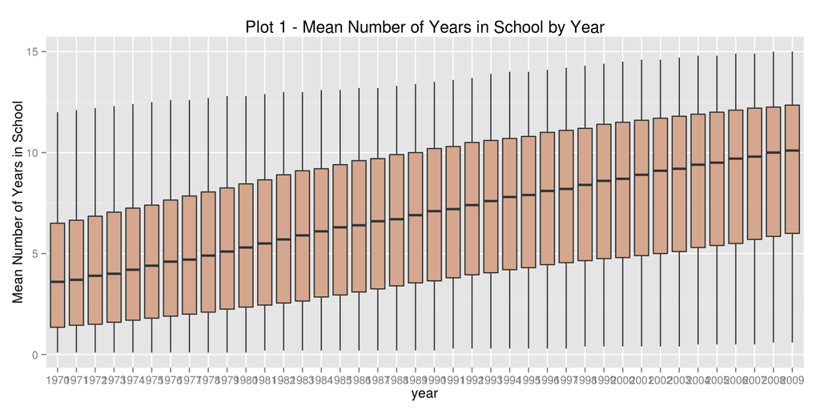

```r
library(ggplot2)

qplot(data = gather.school, x = year, y = mean.num.years,
      geom = 'boxplot', fill = I('#D4A78E'),
      main = "Plot 1 - Mean Number of Years in School by Year") +
  ylab("Mean Number of Years in School")
```

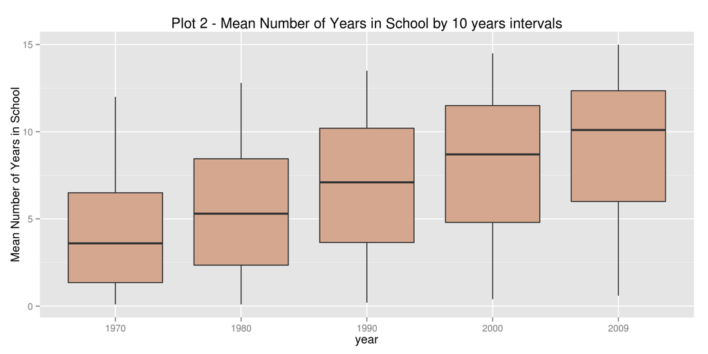

```r
qplot(data = filter(gather.school, year %in% c(1970,1980,1990,2000,2009)),
      x = year, y = mean.num.years,
      geom = 'boxplot', fill = I('#D4A78E'),
      main = "Plot 2 - Mean Number of Years in School by 10 years intervals") +
  ylab("Mean Number of Years in School")
```

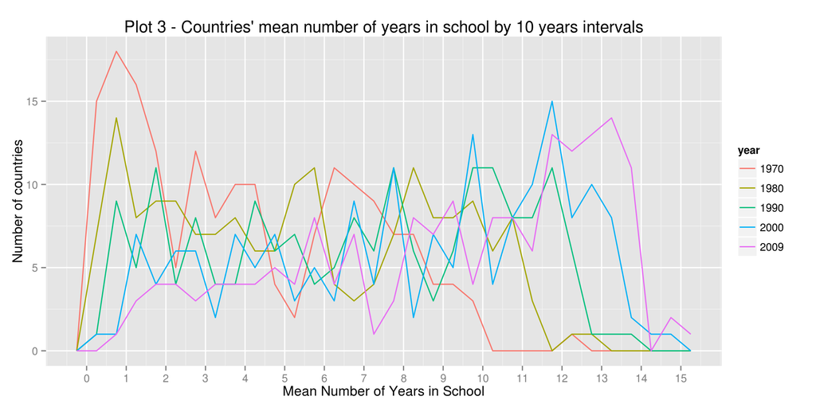

```r
qplot(data = filter(gather.school, year %in% c(1970,1980,1990,2000,2009)),
      x = mean.num.years, binwidth = .5, color = year, geom='freqpoly',
      main = "Plot 3 - Countries' mean number of years in school by 10 years intervals") +
  scale_x_continuous(breaks = seq(0,15, 1)) +
  xlab("Mean Number of Years in School") +
  ylab("Number of countries")
```

The number of years spent in school has an overall increase through the years.  
In plot 3, we can observe that the number of countries with a value of 1 as mean number of years in school, is much lower in recent years. The opposite happens for a value of 12.  
However, looking at plot 1 and 2, one can also notice that the upper limits have been growing at a different rate than the lower limits.

### Range of values by decade

Now we take a closer look at an observation made before: the difference between the extremes in the distribution as well as the interquartile range of the values. The objective is to investigate the evolution of the gap between the countries with the highest and lowest values.

```r
diff.by.year <- gather.school %>%
  group_by(year) %>%
  arrange(mean.num.years) %>%
  summarise(min = first(mean.num.years), max = last(mean.num.years))

diff.by.year %>%
  mutate(decade = paste0(substr(year,1,3),0)) %>%
  group_by(decade) %>%
  summarise(min.value = mean(min), max.value = mean(max), diff.max.min = mean(max - min))
```

```
## Source: local data frame [4 x 4]
##
##   decade min.value max.value diff.max.min
## 1   1970      0.10     12.42        12.32
## 2   1980      0.19     13.10        12.91
## 3   1990      0.31     13.97        13.66
## 4   2000      0.48     14.78        14.30
```

However, many times the extremes are not representative of the overall behavior of the distribution, so a better tool would be to use the interquartile range(IQR) to look into the range of the most common values.

```r
gather.school  %>%
  group_by(year) %>%
  summarise(iqr = IQR(mean.num.years)) %>%
  mutate(decade = paste0(substr(year,1,3),0)) %>%
  group_by(decade) %>%
  summarise(mean.iqr = mean(iqr))
```

```
## Source: local data frame [4 x 2]
##
##   decade mean.iqr
## 1   1970    5.585
## 2   1980    6.380
## 3   1990    6.545
## 4   2000    6.585
```

The gap between the countries with lower mean years spent in school and higher has been increasing per decade.

### Range of values by country

Let’s look at the differences between 1970 and 2009 by country. That is, the difference between the mean number of years spent in school in 2009 and in 1970. This will tell us how much each country has changed in the past 4 decades, and in which direction.

```r
diff.1970.2009 <- mutate(gather.school %>%
  group_by(country) %>%
  summarise(in.1970 = first(mean.num.years), in.2009=last(mean.num.years)), diff = in.2009 - in.1970)

summary(diff.1970.2009$diff)
```

```
##    Min. 1st Qu.  Median    Mean 3rd Qu.    Max.
##   0.500   4.100   5.300   5.126   6.300   9.500
```

The first observation is that every country has increased the mean number of years spent in school. Looking at the values of the mean and median we can also see that the average increase is just over 5 years, which represents a growth of more than 1 year per decade. We can plot these values to have a more detailed view.

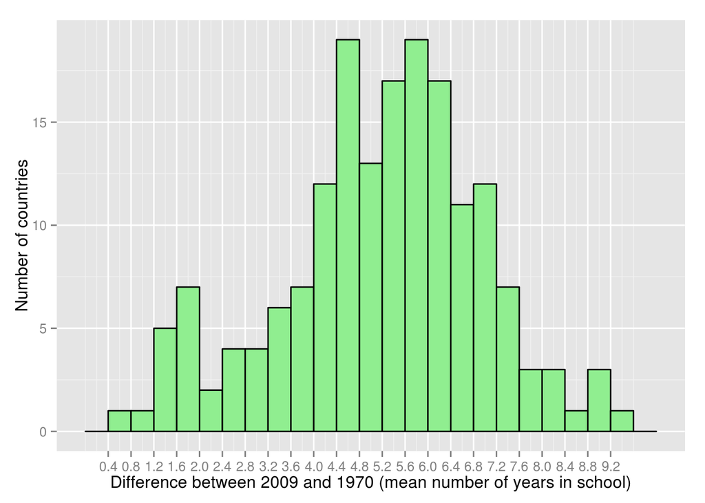

```r
qplot(data = diff.1970.2009, x = diff, binwidth = 0.4, fill = I('light green'), color = I('black')) +
  scale_x_continuous(breaks = seq(0.4, 9.5, 0.4)) +
  ylab("Number of countries") +
  xlab("Difference between 2009 and 1970 (mean number of years in school)")
```

#### Countries with the highest increase

```r
diff.1970.2009 %>%
  arrange(desc(diff)) %>%
  select(country, diff) %>%
  slice(1:5)
```

```
## Source: local data frame [5 x 2]
##
##                country diff
## 1               Taiwan  9.5
## 2               Jordan  9.0
## 3 United Arab Emirates  9.0
## 4              Bahrain  8.8
## 5             Malaysia  8.4
```

#### Countries with lowest increase

```r
diff.1970.2009 %>%
  arrange(diff) %>%
  select(country, diff) %>%
  slice(1:5)
```

```
## Source: local data frame [5 x 2]
##
##        country diff
## 1  Afghanistan  0.5
## 2         Mali  1.0
## 3         Chad  1.2
## 4        Niger  1.2
## 5 Burkina Faso  1.3
```

### General Conclusions

With this study we are able to observe:

1. The increase throughout the years, for every country, of the mean number of years spent in school.
2. The range of values is increasing due to the bottom values increasing at a slower pace than the top values.
3. The countries have been improving at very different paces.

### Future Work

Gather more information on the countries that not only add more context to the study, but may also help understand some of the results that were presented before (highest and lowest values, …).  
For example:

1. Geographical information (continent, region);
2. Cultural traditions;
3. GDP of the countries;
4. Important events (wars, natural disasters, new politics);

Also, one can choose an important event in a particular year and investigate if this event had any change in the values observed during and after. For example: a war (or the end of a war), a change in political regimes, etc..

Sara Carvalho 01-05-2015